# Risk Factor Analysis

## Outcome Variable

**Outcome Variable:** swasted

## Predictor Variables

**Intervention Variable:** hhwealth_quart

**Adjustment Set:**

- arm
- sex
- W_mage
- meducyrs
- feducyrs
- W_gagebrth
- W_birthwt
- W_birthlen
- W_nchldlt5
- W_parity
- delta_W_mage
- delta_meducyrs
- delta_feducyrs
- delta_W_gagebrth
- delta_W_birthwt
- delta_W_birthlen
- delta_W_nchldlt5
- delta_W_parity

## Stratifying Variables

The analysis was stratified on these variable(s):

- agecat
- studyid
- country

## Data Summary

| agecat | studyid | country | hhwealth_quart | swasted | n_cell | n |
| --- | --- | --- | --- | --- | --- | --- |
| Birth | ki0047075b-MAL-ED | BANGLADESH | Wealth Q4 | 0 | 21 | 76 |
| Birth | ki0047075b-MAL-ED | BANGLADESH | Wealth Q4 | 1 | 0 | 76 |
| Birth | ki0047075b-MAL-ED | BANGLADESH | Wealth Q1 | 0 | 17 | 76 |
| Birth | ki0047075b-MAL-ED | BANGLADESH | Wealth Q1 | 1 | 0 | 76 |
| Birth | ki0047075b-MAL-ED | BANGLADESH | Wealth Q2 | 0 | 16 | 76 |
| Birth | ki0047075b-MAL-ED | BANGLADESH | Wealth Q2 | 1 | 2 | 76 |
| Birth | ki0047075b-MAL-ED | BANGLADESH | Wealth Q3 | 0 | 20 | 76 |
| Birth | ki0047075b-MAL-ED | BANGLADESH | Wealth Q3 | 1 | 0 | 76 |
| Birth | ki0047075b-MAL-ED | INDIA | Wealth Q4 | 0 | 11 | 54 |
| Birth | ki0047075b-MAL-ED | INDIA | Wealth Q4 | 1 | 0 | 54 |
| Birth | ki0047075b-MAL-ED | INDIA | Wealth Q1 | 0 | 14 | 54 |
| Birth | ki0047075b-MAL-ED | INDIA | Wealth Q1 | 1 | 3 | 54 |
| Birth | ki0047075b-MAL-ED | INDIA | Wealth Q2 | 0 | 15 | 54 |
| Birth | ki0047075b-MAL-ED | INDIA | Wealth Q2 | 1 | 0 | 54 |
| Birth | ki0047075b-MAL-ED | INDIA | Wealth Q3 | 0 | 11 | 54 |
| Birth | ki0047075b-MAL-ED | INDIA | Wealth Q3 | 1 | 0 | 54 |
| Birth | ki0047075b-MAL-ED | NEPAL | Wealth Q4 | 0 | 9 | 30 |
| Birth | ki0047075b-MAL-ED | NEPAL | Wealth Q4 | 1 | 0 | 30 |
| Birth | ki0047075b-MAL-ED | NEPAL | Wealth Q1 | 0 | 8 | 30 |
| Birth | ki0047075b-MAL-ED | NEPAL | Wealth Q1 | 1 | 0 | 30 |
| Birth | ki0047075b-MAL-ED | NEPAL | Wealth Q2 | 0 | 5 | 30 |
| Birth | ki0047075b-MAL-ED | NEPAL | Wealth Q2 | 1 | 1 | 30 |
| Birth | ki0047075b-MAL-ED | NEPAL | Wealth Q3 | 0 | 7 | 30 |
| Birth | ki0047075b-MAL-ED | NEPAL | Wealth Q3 | 1 | 0 | 30 |
| Birth | ki0047075b-MAL-ED | PERU | Wealth Q4 | 0 | 10 | 36 |
| Birth | ki0047075b-MAL-ED | PERU | Wealth Q4 | 1 | 0 | 36 |
| Birth | ki0047075b-MAL-ED | PERU | Wealth Q1 | 0 | 9 | 36 |
| Birth | ki0047075b-MAL-ED | PERU | Wealth Q1 | 1 | 0 | 36 |
| Birth | ki0047075b-MAL-ED | PERU | Wealth Q2 | 0 | 9 | 36 |
| Birth | ki0047075b-MAL-ED | PERU | Wealth Q2 | 1 | 0 | 36 |

[output cut: 346 more lines]

The following strata were considered:

- agecat: 24 months, studyid: ki0047075b-MAL-ED, country: BANGLADESH
- agecat: 24 months, studyid: ki0047075b-MAL-ED, country: INDIA
- agecat: 24 months, studyid: ki0047075b-MAL-ED, country: NEPAL
- agecat: 24 months, studyid: ki0047075b-MAL-ED, country: PERU
- agecat: 24 months, studyid: ki0047075b-MAL-ED, country: SOUTH AFRICA
- agecat: 24 months, studyid: ki0047075b-MAL-ED, country: TANZANIA, UNITED REPUBLIC OF
- agecat: 24 months, studyid: ki1000108-CMC-V-BCS-2002, country: INDIA
- agecat: 24 months, studyid: ki1000108-IRC, country: INDIA
- agecat: 24 months, studyid: ki1017093b-PROVIDE, country: BANGLADESH
- agecat: 24 months, studyid: ki1066203-TanzaniaChild2, country: TANZANIA, UNITED REPUBLIC OF
- agecat: 24 months, studyid: ki1113344-GMS-Nepal, country: NEPAL
- agecat: 24 months, studyid: ki1114097-CONTENT, country: PERU
- agecat: 24 months, studyid: ki1135781-COHORTS, country: GUATEMALA
- agecat: 24 months, studyid: ki1135781-COHORTS, country: PHILIPPINES
- agecat: 24 months, studyid: ki1148112-LCNI-5, country: MALAWI
- agecat: 24 months, studyid: kiGH5241-JiVitA-3, country: BANGLADESH
- agecat: 24 months, studyid: kiGH5241-JiVitA-4, country: BANGLADESH
- agecat: 6 months, studyid: ki0047075b-MAL-ED, country: BANGLADESH
- agecat: 6 months, studyid: ki0047075b-MAL-ED, country: INDIA
- agecat: 6 months, studyid: ki0047075b-MAL-ED, country: NEPAL
- agecat: 6 months, studyid: ki0047075b-MAL-ED, country: PERU
- agecat: 6 months, studyid: ki0047075b-MAL-ED, country: SOUTH AFRICA
- agecat: 6 months, studyid: ki0047075b-MAL-ED, country: TANZANIA, UNITED REPUBLIC OF
- agecat: 6 months, studyid: ki1000108-CMC-V-BCS-2002, country: INDIA
- agecat: 6 months, studyid: ki1000108-IRC, country: INDIA
- agecat: 6 months, studyid: ki1017093b-PROVIDE, country: BANGLADESH
- agecat: 6 months, studyid: ki1066203-TanzaniaChild2, country: TANZANIA, UNITED REPUBLIC OF
- agecat: 6 months, studyid: ki1113344-GMS-Nepal, country: NEPAL
- agecat: 6 months, studyid: ki1114097-CONTENT, country: PERU
- agecat: 6 months, studyid: ki1135781-COHORTS, country: GUATEMALA
- agecat: 6 months, studyid: ki1135781-COHORTS, country: PHILIPPINES
- agecat: 6 months, studyid: ki1148112-LCNI-5, country: MALAWI
- agecat: 6 months, studyid: kiGH5241-JiVitA-3, country: BANGLADESH
- agecat: 6 months, studyid: kiGH5241-JiVitA-4, country: BANGLADESH
- agecat: Birth, studyid: ki0047075b-MAL-ED, country: BANGLADESH
- agecat: Birth, studyid: ki0047075b-MAL-ED, country: INDIA
- agecat: Birth, studyid: ki0047075b-MAL-ED, country: NEPAL
- agecat: Birth, studyid: ki0047075b-MAL-ED, country: PERU
- agecat: Birth, studyid: ki0047075b-MAL-ED, country: SOUTH AFRICA
- agecat: Birth, studyid: ki0047075b-MAL-ED, country: TANZANIA, UNITED REPUBLIC OF
- agecat: Birth, studyid: ki1000108-CMC-V-BCS-2002, country: INDIA
- agecat: Birth, studyid: ki1000108-IRC, country: INDIA
- agecat: Birth, studyid: ki1114097-CONTENT, country: PERU
- agecat: Birth, studyid: ki1135781-COHORTS, country: GUATEMALA
- agecat: Birth, studyid: ki1135781-COHORTS, country: PHILIPPINES
- agecat: Birth, studyid: kiGH5241-JiVitA-3, country: BANGLADESH
- agecat: Birth, studyid: kiGH5241-JiVitA-4, country: BANGLADESH

### Dropped Strata

Some strata were dropped due to rare outcomes:

- agecat: Birth, studyid: ki0047075b-MAL-ED, country: BANGLADESH
- agecat: Birth, studyid: ki0047075b-MAL-ED, country: INDIA
- agecat: Birth, studyid: ki0047075b-MAL-ED, country: NEPAL
- agecat: Birth, studyid: ki0047075b-MAL-ED, country: PERU
- agecat: Birth, studyid: ki0047075b-MAL-ED, country: SOUTH AFRICA
- agecat: Birth, studyid: ki0047075b-MAL-ED, country: TANZANIA, UNITED REPUBLIC OF
- agecat: Birth, studyid: ki1000108-CMC-V-BCS-2002, country: INDIA
- agecat: Birth, studyid: ki1114097-CONTENT, country: PERU
- agecat: Birth, studyid: kiGH5241-JiVitA-4, country: BANGLADESH
- agecat: 6 months, studyid: ki0047075b-MAL-ED, country: BANGLADESH
- agecat: 6 months, studyid: ki0047075b-MAL-ED, country: INDIA
- agecat: 6 months, studyid: ki0047075b-MAL-ED, country: NEPAL
- agecat: 6 months, studyid: ki0047075b-MAL-ED, country: PERU
- agecat: 6 months, studyid: ki0047075b-MAL-ED, country: SOUTH AFRICA
- agecat: 6 months, studyid: ki0047075b-MAL-ED, country: TANZANIA, UNITED REPUBLIC OF
- agecat: 6 months, studyid: ki1000108-CMC-V-BCS-2002, country: INDIA
- agecat: 6 months, studyid: ki1000108-IRC, country: INDIA
- agecat: 6 months, studyid: ki1017093b-PROVIDE, country: BANGLADESH
- agecat: 6 months, studyid: ki1066203-TanzaniaChild2, country: TANZANIA, UNITED REPUBLIC OF
- agecat: 6 months, studyid: ki1113344-GMS-Nepal, country: NEPAL
- agecat: 6 months, studyid: ki1114097-CONTENT, country: PERU
- agecat: 6 months, studyid: ki1135781-COHORTS, country: GUATEMALA
- agecat: 6 months, studyid: ki1148112-LCNI-5, country: MALAWI
- agecat: 6 months, studyid: kiGH5241-JiVitA-4, country: BANGLADESH
- agecat: 24 months, studyid: ki0047075b-MAL-ED, country: BANGLADESH
- agecat: 24 months, studyid: ki0047075b-MAL-ED, country: INDIA
- agecat: 24 months, studyid: ki0047075b-MAL-ED, country: NEPAL
- agecat: 24 months, studyid: ki0047075b-MAL-ED, country: PERU
- agecat: 24 months, studyid: ki0047075b-MAL-ED, country: SOUTH AFRICA
- agecat: 24 months, studyid: ki0047075b-MAL-ED, country: TANZANIA, UNITED REPUBLIC OF
- agecat: 24 months, studyid: ki1000108-CMC-V-BCS-2002, country: INDIA
- agecat: 24 months, studyid: ki1000108-IRC, country: INDIA
- agecat: 24 months, studyid: ki1017093b-PROVIDE, country: BANGLADESH
- agecat: 24 months, studyid: ki1066203-TanzaniaChild2, country: TANZANIA, UNITED REPUBLIC OF
- agecat: 24 months, studyid: ki1113344-GMS-Nepal, country: NEPAL
- agecat: 24 months, studyid: ki1114097-CONTENT, country: PERU
- agecat: 24 months, studyid: ki1135781-COHORTS, country: GUATEMALA
- agecat: 24 months, studyid: ki1135781-COHORTS, country: PHILIPPINES
- agecat: 24 months, studyid: ki1148112-LCNI-5, country: MALAWI

## Methods Detail

We’re interested in the causal parameters $E[Y_a]$ for all values of $a \in \mathcal{A}$. These parameters represent the mean outcome if, possibly contrary to fact, we intervened to set all units to have $A=a$. Under the randomization and positivity assumptions, these are identified by the statistical parameters $\psi_a=E_W[E_{Y|A,W}(Y|A=a,W)]$. In addition, we’re interested in the mean of $Y$, $E[Y]$ under no intervention (the observed mean). We will estimate these parameters by using SuperLearner to fit the relevant likelihood factors – $E_{Y|A,W}(Y|A=a,W)$ and $p(A=a|W)$, and then updating our likelihood fit using a joint TMLE.

For unadjusted analyses ($W=\{\}$), initial likelihoods were estimated using Lrnr_glm to estimate the simple $E(Y|A)$ and Lrnr_mean to estimate $p(A)$. For adjusted analyses, a small library containing Lrnr_glmnet, Lrnr_xgboost, and Lrnr_mean was used.

Having estimated these parameters, we will then use the delta method to estimate relative risks and attributable risks relative to a prespecified baseline level of $A$.

# Results Detail

## Results Plots

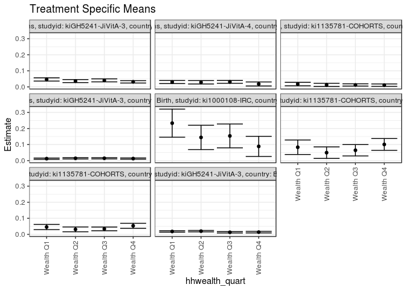

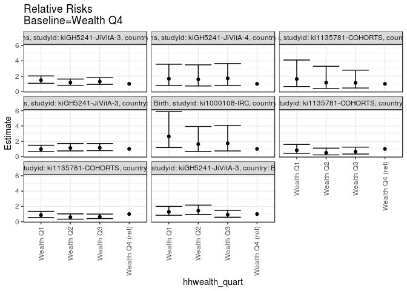

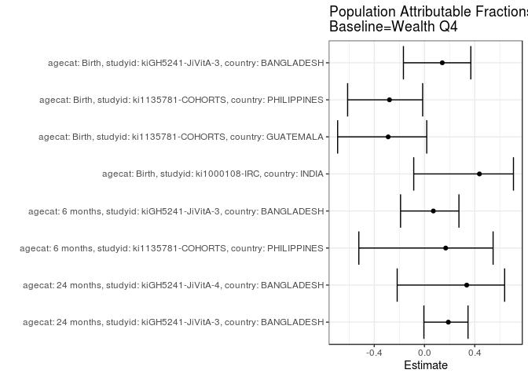

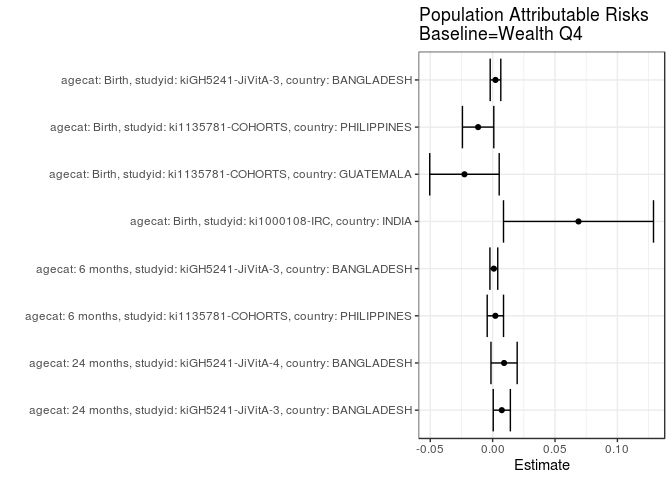

## Results Table

### Parameter: TSM

| agecat | studyid | country | intervention_level | baseline_level | estimate | ci_lower | ci_upper |
| --- | --- | --- | --- | --- | --- | --- | --- |
| Birth | ki1000108-IRC | INDIA | Wealth Q4 | NA | 0.0886076 | 0.0258514 | 0.1513638 |
| Birth | ki1000108-IRC | INDIA | Wealth Q1 | NA | 0.2333333 | 0.1458244 | 0.3208423 |
| Birth | ki1000108-IRC | INDIA | Wealth Q2 | NA | 0.1445783 | 0.0688105 | 0.2203461 |
| Birth | ki1000108-IRC | INDIA | Wealth Q3 | NA | 0.1538462 | 0.0796076 | 0.2280847 |
| Birth | ki1135781-COHORTS | GUATEMALA | Wealth Q4 | NA | 0.1007752 | 0.0640176 | 0.1375328 |
| Birth | ki1135781-COHORTS | GUATEMALA | Wealth Q1 | NA | 0.0833333 | 0.0381602 | 0.1285064 |
| Birth | ki1135781-COHORTS | GUATEMALA | Wealth Q2 | NA | 0.0496454 | 0.0137682 | 0.0855226 |
| Birth | ki1135781-COHORTS | GUATEMALA | Wealth Q3 | NA | 0.0645161 | 0.0291863 | 0.0998460 |
| Birth | ki1135781-COHORTS | PHILIPPINES | Wealth Q4 | NA | 0.0533959 | 0.0377624 | 0.0690294 |
| Birth | ki1135781-COHORTS | PHILIPPINES | Wealth Q1 | NA | 0.0457185 | 0.0296105 | 0.0618266 |
| Birth | ki1135781-COHORTS | PHILIPPINES | Wealth Q2 | NA | 0.0310590 | 0.0161652 | 0.0459529 |
| Birth | ki1135781-COHORTS | PHILIPPINES | Wealth Q3 | NA | 0.0340204 | 0.0224483 | 0.0455925 |
| Birth | kiGH5241-JiVitA-3 | BANGLADESH | Wealth Q4 | NA | 0.0138971 | 0.0089653 | 0.0188290 |
| Birth | kiGH5241-JiVitA-3 | BANGLADESH | Wealth Q1 | NA | 0.0179767 | 0.0135025 | 0.0224510 |
| Birth | kiGH5241-JiVitA-3 | BANGLADESH | Wealth Q2 | NA | 0.0198975 | 0.0155113 | 0.0242838 |
| Birth | kiGH5241-JiVitA-3 | BANGLADESH | Wealth Q3 | NA | 0.0128688 | 0.0085070 | 0.0172306 |
| 6 months | ki1135781-COHORTS | PHILIPPINES | Wealth Q4 | NA | 0.0107527 | 0.0033404 | 0.0181650 |
| 6 months | ki1135781-COHORTS | PHILIPPINES | Wealth Q1 | NA | 0.0175747 | 0.0067761 | 0.0283733 |
| 6 months | ki1135781-COHORTS | PHILIPPINES | Wealth Q2 | NA | 0.0123711 | 0.0025319 | 0.0222103 |
| 6 months | ki1135781-COHORTS | PHILIPPINES | Wealth Q3 | NA | 0.0121145 | 0.0049976 | 0.0192315 |
| 6 months | kiGH5241-JiVitA-3 | BANGLADESH | Wealth Q4 | NA | 0.0126891 | 0.0088934 | 0.0164848 |
| 6 months | kiGH5241-JiVitA-3 | BANGLADESH | Wealth Q1 | NA | 0.0123171 | 0.0084965 | 0.0161377 |
| 6 months | kiGH5241-JiVitA-3 | BANGLADESH | Wealth Q2 | NA | 0.0143076 | 0.0100670 | 0.0185482 |
| 6 months | kiGH5241-JiVitA-3 | BANGLADESH | Wealth Q3 | NA | 0.0146195 | 0.0105576 | 0.0186814 |
| 24 months | kiGH5241-JiVitA-3 | BANGLADESH | Wealth Q4 | NA | 0.0314022 | 0.0240255 | 0.0387789 |
| 24 months | kiGH5241-JiVitA-3 | BANGLADESH | Wealth Q1 | NA | 0.0464200 | 0.0363446 | 0.0564954 |
| 24 months | kiGH5241-JiVitA-3 | BANGLADESH | Wealth Q2 | NA | 0.0361203 | 0.0267669 | 0.0454737 |
| 24 months | kiGH5241-JiVitA-3 | BANGLADESH | Wealth Q3 | NA | 0.0405627 | 0.0312220 | 0.0499034 |
| 24 months | kiGH5241-JiVitA-4 | BANGLADESH | Wealth Q4 | NA | 0.0181059 | 0.0055097 | 0.0307021 |
| 24 months | kiGH5241-JiVitA-4 | BANGLADESH | Wealth Q1 | NA | 0.0301437 | 0.0205675 | 0.0397199 |
| 24 months | kiGH5241-JiVitA-4 | BANGLADESH | Wealth Q2 | NA | 0.0286299 | 0.0180637 | 0.0391961 |
| 24 months | kiGH5241-JiVitA-4 | BANGLADESH | Wealth Q3 | NA | 0.0310645 | 0.0222202 | 0.0399089 |

### Parameter: E(Y)

| agecat | studyid | country | intervention_level | baseline_level | estimate | ci_lower | ci_upper |
| --- | --- | --- | --- | --- | --- | --- | --- |
| Birth | ki1000108-IRC | INDIA | NA | NA | 0.1574344 | 0.1188345 | 0.1960344 |
| Birth | ki1135781-COHORTS | GUATEMALA | NA | NA | 0.0781893 | 0.0586874 | 0.0976912 |
| Birth | ki1135781-COHORTS | PHILIPPINES | NA | NA | 0.0417529 | 0.0344692 | 0.0490367 |
| Birth | kiGH5241-JiVitA-3 | BANGLADESH | NA | NA | 0.0161876 | 0.0138223 | 0.0185529 |
| 6 months | ki1135781-COHORTS | PHILIPPINES | NA | NA | 0.0129342 | 0.0086762 | 0.0171922 |
| 6 months | kiGH5241-JiVitA-3 | BANGLADESH | NA | NA | 0.0136505 | 0.0115778 | 0.0157231 |
| 24 months | kiGH5241-JiVitA-3 | BANGLADESH | NA | NA | 0.0387480 | 0.0344217 | 0.0430742 |
| 24 months | kiGH5241-JiVitA-4 | BANGLADESH | NA | NA | 0.0272727 | 0.0220640 | 0.0324815 |

### Parameter: RR

| agecat | studyid | country | intervention_level | baseline_level | estimate | ci_lower | ci_upper |
| --- | --- | --- | --- | --- | --- | --- | --- |
| Birth | ki1000108-IRC | INDIA | Wealth Q4 | Wealth Q4 | 1.0000000 | 1.0000000 | 1.0000000 |
| Birth | ki1000108-IRC | INDIA | Wealth Q1 | Wealth Q4 | 2.6333330 | 1.1815568 | 5.8689030 |
| Birth | ki1000108-IRC | INDIA | Wealth Q2 | Wealth Q4 | 1.6316693 | 0.6760758 | 3.9379384 |
| Birth | ki1000108-IRC | INDIA | Wealth Q3 | Wealth Q4 | 1.7362635 | 0.7369189 | 4.0908314 |
| Birth | ki1135781-COHORTS | GUATEMALA | Wealth Q4 | Wealth Q4 | 1.0000000 | 1.0000000 | 1.0000000 |
| Birth | ki1135781-COHORTS | GUATEMALA | Wealth Q1 | Wealth Q4 | 0.8269231 | 0.4302403 | 1.5893484 |
| Birth | ki1135781-COHORTS | GUATEMALA | Wealth Q2 | Wealth Q4 | 0.4926350 | 0.2192618 | 1.1068468 |
| Birth | ki1135781-COHORTS | GUATEMALA | Wealth Q3 | Wealth Q4 | 0.6401985 | 0.3315606 | 1.2361364 |
| Birth | ki1135781-COHORTS | PHILIPPINES | Wealth Q4 | Wealth Q4 | 1.0000000 | 1.0000000 | 1.0000000 |
| Birth | ki1135781-COHORTS | PHILIPPINES | Wealth Q1 | Wealth Q4 | 0.8562179 | 0.5418743 | 1.3529136 |
| Birth | ki1135781-COHORTS | PHILIPPINES | Wealth Q2 | Wealth Q4 | 0.5816747 | 0.3318921 | 1.0194440 |
| Birth | ki1135781-COHORTS | PHILIPPINES | Wealth Q3 | Wealth Q4 | 0.6371347 | 0.4071712 | 0.9969778 |
| Birth | kiGH5241-JiVitA-3 | BANGLADESH | Wealth Q4 | Wealth Q4 | 1.0000000 | 1.0000000 | 1.0000000 |
| Birth | kiGH5241-JiVitA-3 | BANGLADESH | Wealth Q1 | Wealth Q4 | 1.2935579 | 0.8368800 | 1.9994408 |
| Birth | kiGH5241-JiVitA-3 | BANGLADESH | Wealth Q2 | Wealth Q4 | 1.4317728 | 0.9451986 | 2.1688283 |
| Birth | kiGH5241-JiVitA-3 | BANGLADESH | Wealth Q3 | Wealth Q4 | 0.9260035 | 0.5805901 | 1.4769154 |
| 6 months | ki1135781-COHORTS | PHILIPPINES | Wealth Q4 | Wealth Q4 | 1.0000000 | 1.0000000 | 1.0000000 |
| 6 months | ki1135781-COHORTS | PHILIPPINES | Wealth Q1 | Wealth Q4 | 1.6344464 | 0.6491256 | 4.1154054 |
| 6 months | ki1135781-COHORTS | PHILIPPINES | Wealth Q2 | Wealth Q4 | 1.1505155 | 0.4016045 | 3.2959934 |
| 6 months | ki1135781-COHORTS | PHILIPPINES | Wealth Q3 | Wealth Q4 | 1.1266520 | 0.4554533 | 2.7869920 |
| 6 months | kiGH5241-JiVitA-3 | BANGLADESH | Wealth Q4 | Wealth Q4 | 1.0000000 | 1.0000000 | 1.0000000 |
| 6 months | kiGH5241-JiVitA-3 | BANGLADESH | Wealth Q1 | Wealth Q4 | 0.9706859 | 0.6360404 | 1.4814014 |
| 6 months | kiGH5241-JiVitA-3 | BANGLADESH | Wealth Q2 | Wealth Q4 | 1.1275498 | 0.7414261 | 1.7147611 |
| 6 months | kiGH5241-JiVitA-3 | BANGLADESH | Wealth Q3 | Wealth Q4 | 1.1521306 | 0.7750540 | 1.7126613 |
| 24 months | kiGH5241-JiVitA-3 | BANGLADESH | Wealth Q4 | Wealth Q4 | 1.0000000 | 1.0000000 | 1.0000000 |
| 24 months | kiGH5241-JiVitA-3 | BANGLADESH | Wealth Q1 | Wealth Q4 | 1.4782410 | 1.0731480 | 2.0362491 |
| 24 months | kiGH5241-JiVitA-3 | BANGLADESH | Wealth Q2 | Wealth Q4 | 1.1502483 | 0.8136468 | 1.6261001 |
| 24 months | kiGH5241-JiVitA-3 | BANGLADESH | Wealth Q3 | Wealth Q4 | 1.2917157 | 0.9298511 | 1.7944049 |
| 24 months | kiGH5241-JiVitA-4 | BANGLADESH | Wealth Q4 | Wealth Q4 | 1.0000000 | 1.0000000 | 1.0000000 |
| 24 months | kiGH5241-JiVitA-4 | BANGLADESH | Wealth Q1 | Wealth Q4 | 1.6648568 | 0.7779325 | 3.5629676 |
| 24 months | kiGH5241-JiVitA-4 | BANGLADESH | Wealth Q2 | Wealth Q4 | 1.5812480 | 0.7182036 | 3.4813877 |
| 24 months | kiGH5241-JiVitA-4 | BANGLADESH | Wealth Q3 | Wealth Q4 | 1.7157144 | 0.8064795 | 3.6500319 |

### Parameter: PAR

| agecat | studyid | country | intervention_level | baseline_level | estimate | ci_lower | ci_upper |
| --- | --- | --- | --- | --- | --- | --- | --- |
| Birth | ki1000108-IRC | INDIA | Wealth Q4 | NA | 0.0688268 | 0.0087091 | 0.1289445 |
| Birth | ki1135781-COHORTS | GUATEMALA | Wealth Q4 | NA | -0.0225859 | -0.0504264 | 0.0052547 |
| Birth | ki1135781-COHORTS | PHILIPPINES | Wealth Q4 | NA | -0.0116430 | -0.0242119 | 0.0009259 |
| Birth | kiGH5241-JiVitA-3 | BANGLADESH | Wealth Q4 | NA | 0.0022905 | -0.0019599 | 0.0065408 |
| 6 months | ki1135781-COHORTS | PHILIPPINES | Wealth Q4 | NA | 0.0021815 | -0.0043653 | 0.0087283 |
| 6 months | kiGH5241-JiVitA-3 | BANGLADESH | Wealth Q4 | NA | 0.0009614 | -0.0021711 | 0.0040938 |
| 24 months | kiGH5241-JiVitA-3 | BANGLADESH | Wealth Q4 | NA | 0.0073458 | 0.0004821 | 0.0142095 |
| 24 months | kiGH5241-JiVitA-4 | BANGLADESH | Wealth Q4 | NA | 0.0091668 | -0.0013380 | 0.0196717 |

### Parameter: PAF

| agecat | studyid | country | intervention_level | baseline_level | estimate | ci_lower | ci_upper |
| --- | --- | --- | --- | --- | --- | --- | --- |
| Birth | ki1000108-IRC | INDIA | Wealth Q4 | NA | 0.4371776 | -0.0857091 | 0.7082377 |
| Birth | ki1135781-COHORTS | GUATEMALA | Wealth Q4 | NA | -0.2888617 | -0.6914201 | 0.0178877 |
| Birth | ki1135781-COHORTS | PHILIPPINES | Wealth Q4 | NA | -0.2788540 | -0.6119794 | -0.0145710 |
| Birth | kiGH5241-JiVitA-3 | BANGLADESH | Wealth Q4 | NA | 0.1414967 | -0.1676770 | 0.3688083 |
| 6 months | ki1135781-COHORTS | PHILIPPINES | Wealth Q4 | NA | 0.1686636 | -0.5227820 | 0.5461463 |
| 6 months | kiGH5241-JiVitA-3 | BANGLADESH | Wealth Q4 | NA | 0.0704272 | -0.1904921 | 0.2741610 |
| 24 months | kiGH5241-JiVitA-3 | BANGLADESH | Wealth Q4 | NA | 0.1895784 | -0.0048996 | 0.3464191 |
| 24 months | kiGH5241-JiVitA-4 | BANGLADESH | Wealth Q4 | NA | 0.3361173 | -0.2174061 | 0.6379677 |